# Содержание

Построим диаграммы рассеяния для целевого признака модели линейной регрессии — `удой_кг` и всех числовых признаков с учётом значения категориального признака `порода`:

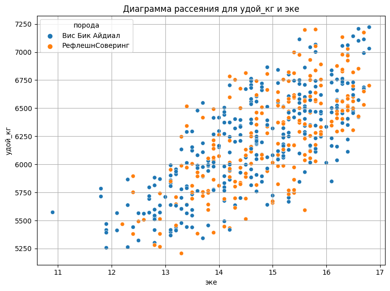

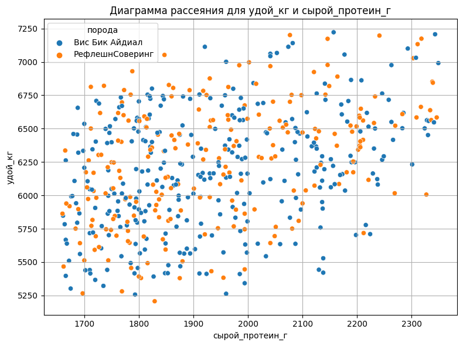

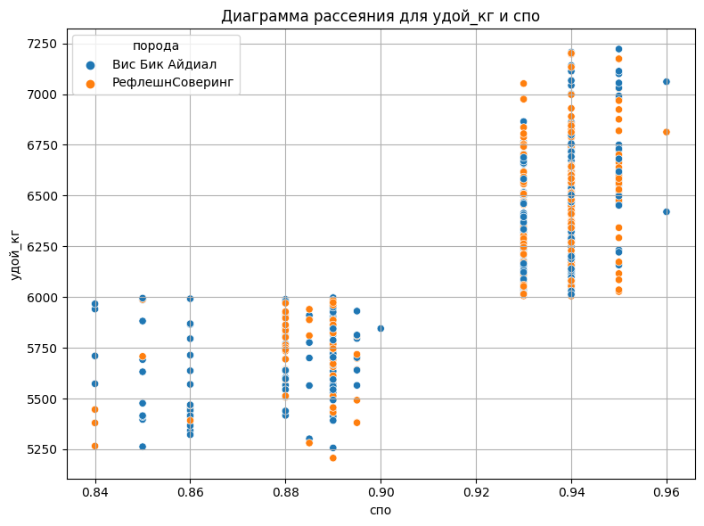

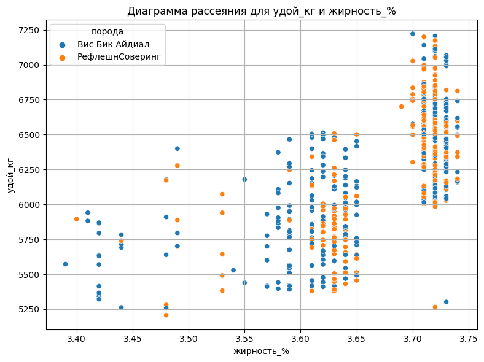

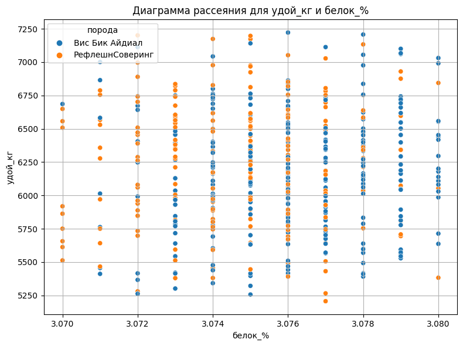

```python
# напишем функцию для построения диаграммы рассеяния для всех числовых признаков
def scatterplot_good_ferma(hue):
    numeric_values = ['эке', 'сырой_протеин_г', 'спо', 'жирность_%', 'белок_%']
    for feature in numeric_values:
        plt.figure(figsize=(8,6))
        sns.scatterplot(data=good_ferma_main, x=feature, y='удой_кг', hue=hue)
        plt.title(f'Диаграмма рассеяния для удой_кг и {feature}')
        plt.grid(True)
        plt.tight_layout()
        plt.show()

# вызовем функцию
scatterplot_good_ferma('порода')
```

Построим диаграммы рассеяния для `удой_кг` и всех числовых признаков с учётом значения категориального признака `тип_пастбища`:

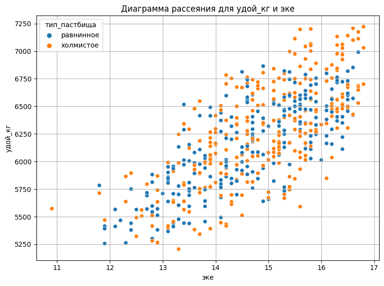

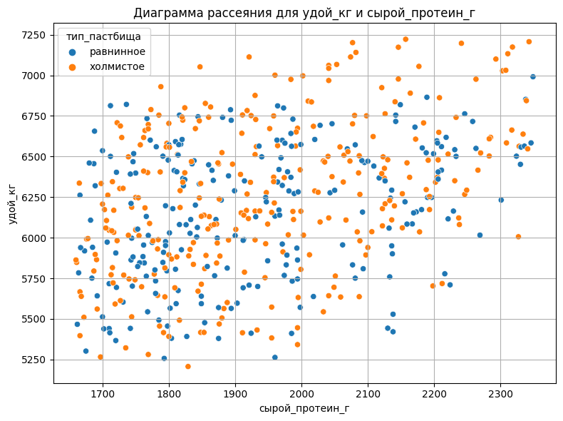

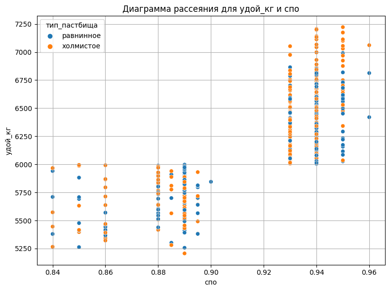

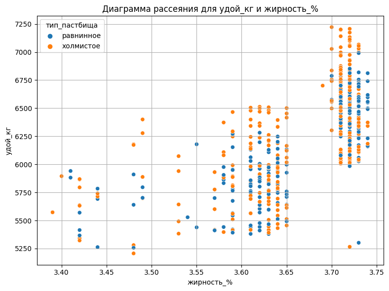

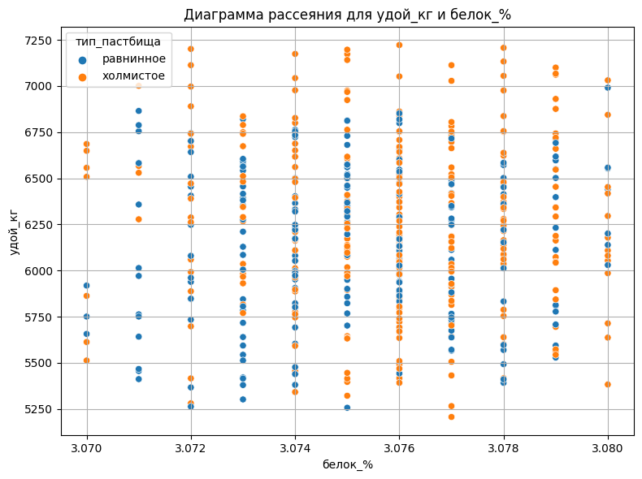

```python
# вызовем функцию для построения диаграммы рассеяния
scatterplot_good_ferma('тип_пастбища')
```

Построим диаграммы рассеяния для удой_кг и всех числовых признаков с учётом значения категориального признака `порода_папы_быка`:

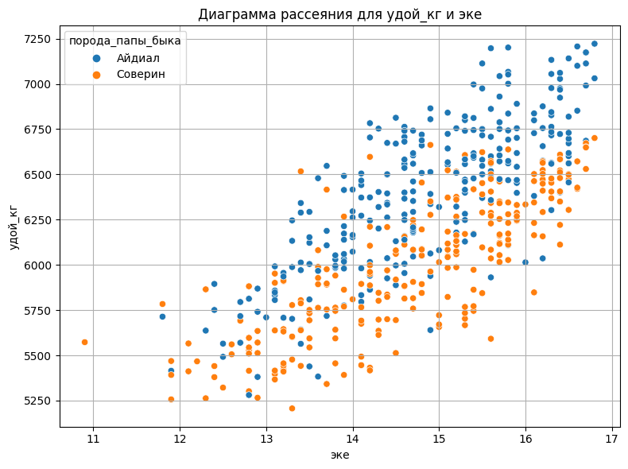

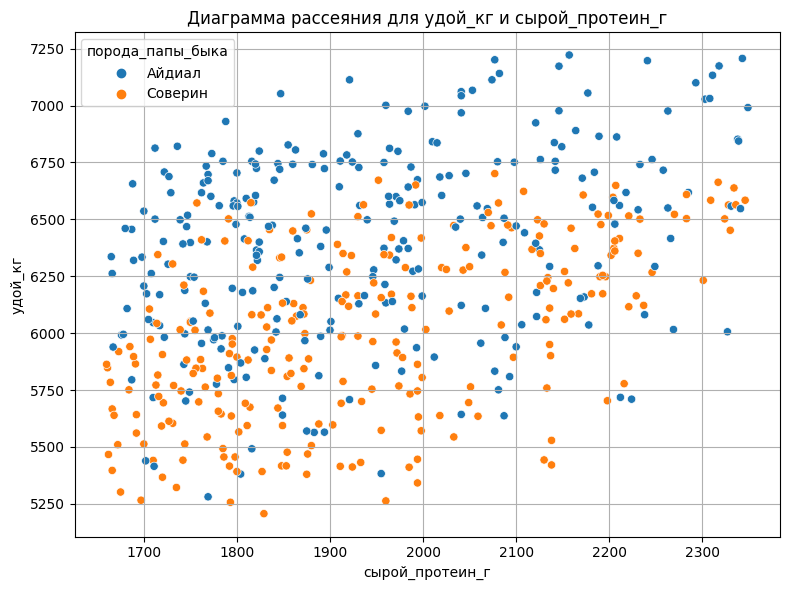

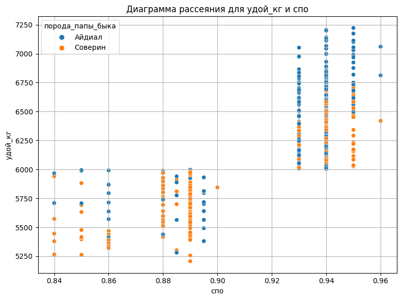

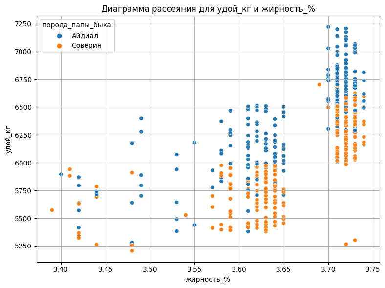

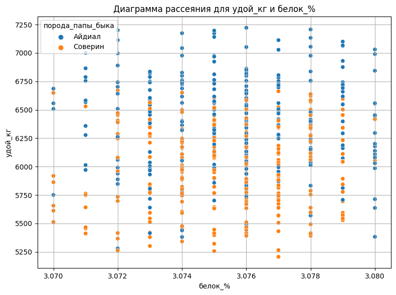

```python
# вызовем функцию для построения диаграммы рассеяния
scatterplot_good_ferma('порода_папы_быка')
```

Построим диаграммы рассеяния для удой_кг и всех числовых признаков с учётом значения категориального признака `вкус_молока`:

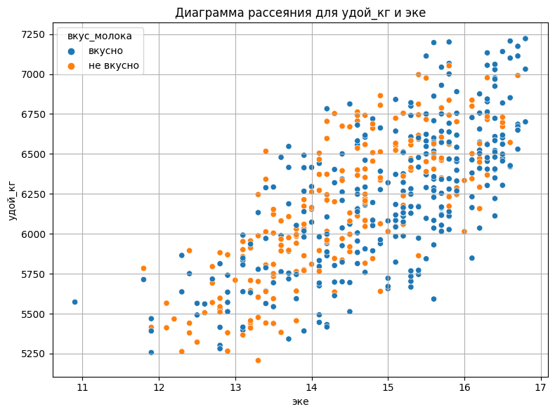

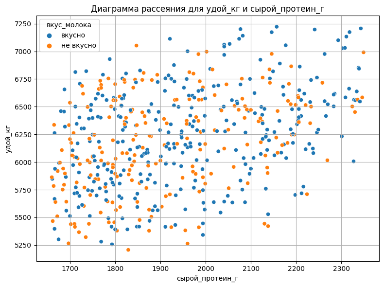

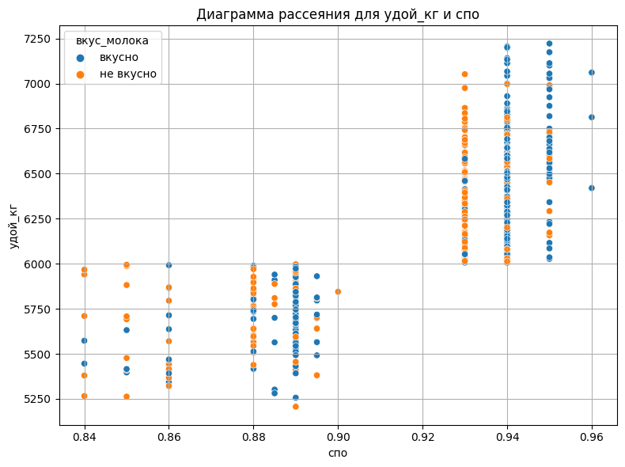

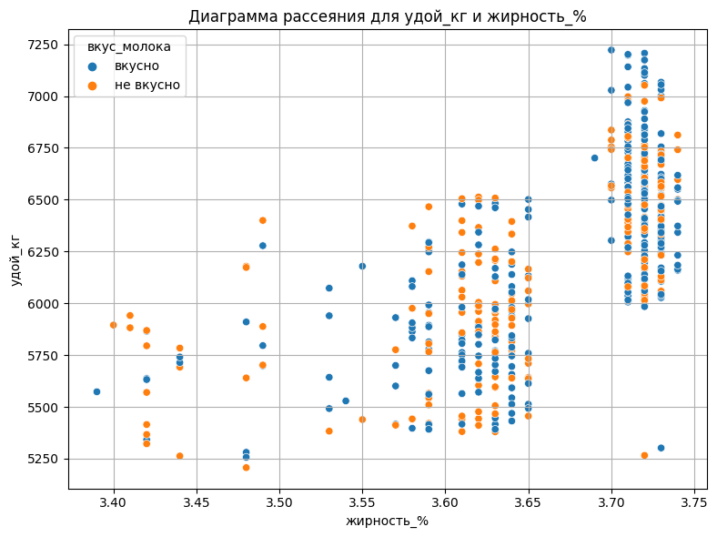

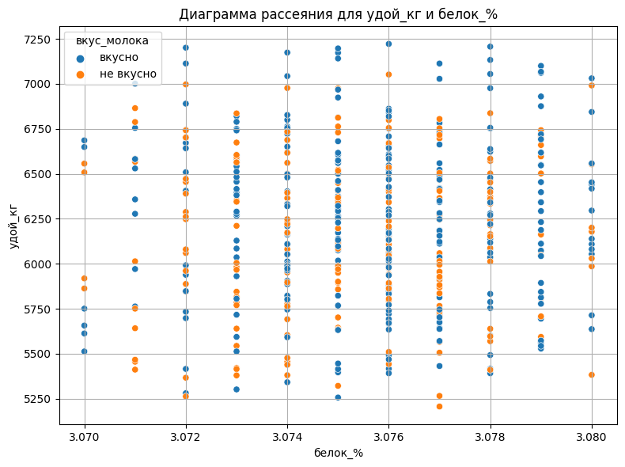

```python
# вызовем функцию для построения диаграммы рассеяния
scatterplot_good_ferma('вкус_молока')
```

Построим диаграммы рассеяния для удой_кг и всех числовых признаков с учётом значения категориального признака `возраст`:

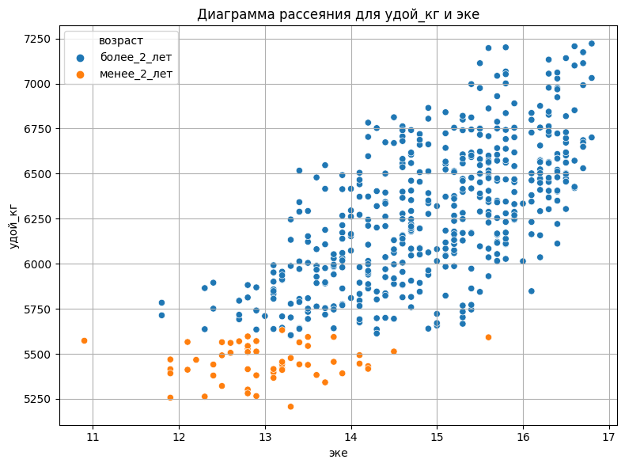

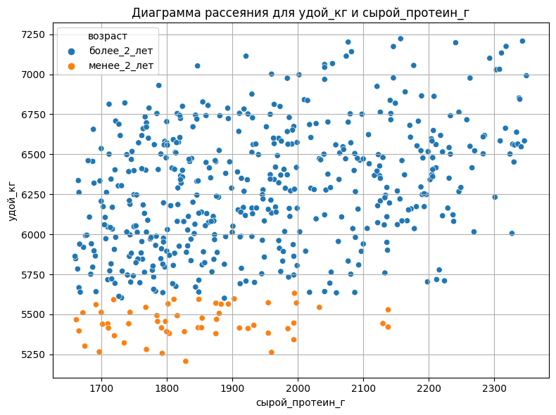

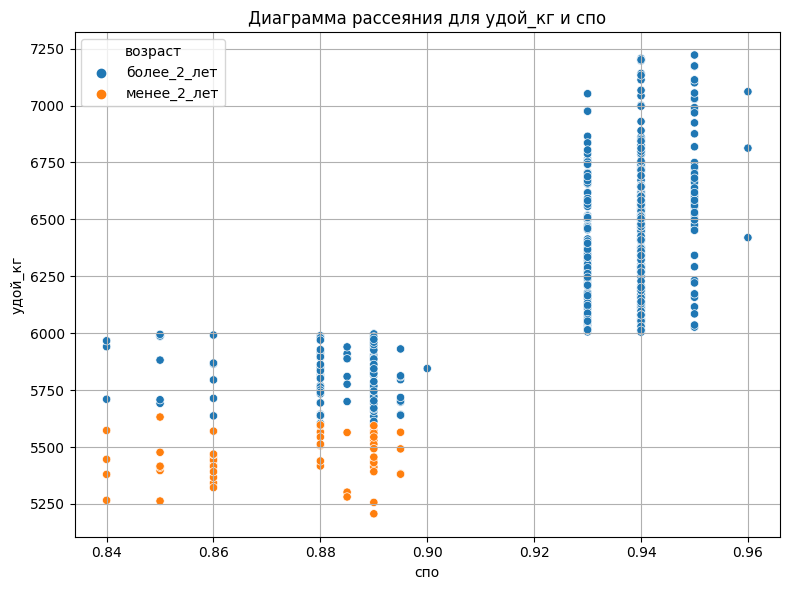

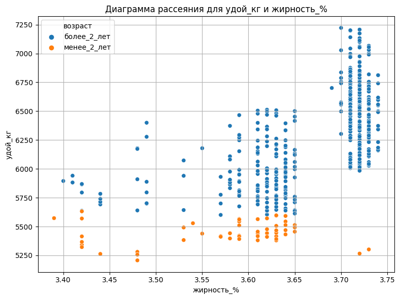

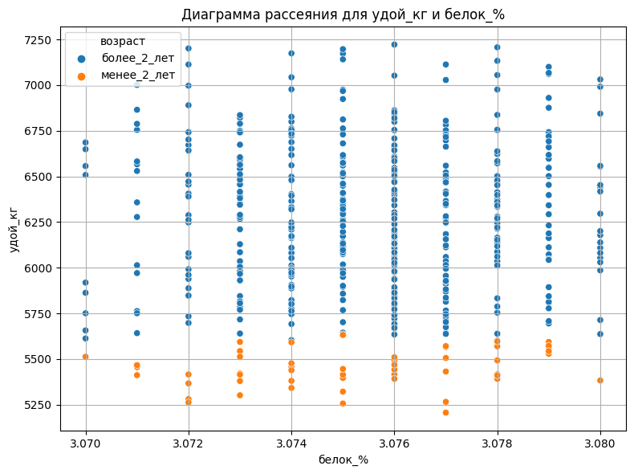

```python
# вызовем функцию для построения диаграммы рассеяния
scatterplot_good_ferma('возраст')
```

**Выводы**:

- Можно выделить признаки, которые не связаны с таргетом `удой_кг` линейно: `эке`, `сырой_протеин_г`, `спо` и `жирность_%`.
- Целевой признак `вкус_молока` коррелирует с `спо`(сахаро-протеиновое соотношение).
- Тепловая карта и `phik_matrix` показывают категориальную зависимость между целевым признаком `удой_кг` и входными признаками `порода_папы_быка`, `возраст`. `Возраст` оказывает значительное влияние на `удой_кг`.
- В данных не наблюдается мультиколлинеарности между входными признаками со значением коэффициента корреляции от 0.9 до 0.95.

## Обучение линейной регрессии

- Обучим **3** модели простой линейной регрессии.
- Оценим качество каждой модели с помощью `анализа остатков` и метрик `R²`, `MSE`, `MAE`, `RMSE`.
- Сравним модели по качеству и сделаем прогноз на новых данных с помощью лучшей модели.

### Обучение первой модели линейной регрессии

Подготовим данные датасета `good_ferma_main` и обучим на них первую модель `LinearRegression`.

```python
# создадим константу RANDOM_STATE
RANDOM_STATE = 42

# отберём признаки, которые подходят для модели линейной регрессии
features = ['эке', 'порода_папы_быка', 'возраст']

# выделим входные признаки и целевой признак
X = good_ferma_main[features]
y = good_ferma_main['удой_кг']
```

- `ЭКЕ (Энергетическая кормовая единица)` влияет на `удой` коровы, так как `эке` это мера энергии, которую корова получает из корма. Чтобы произвести **1** литр молока, корова в среднем тратит от **0.7** до **0.9** ЭКЕ, в зависимости от жирности и качества корма.
- `Порода папы быка` оказывает влияение на `удой` коровы не только из-за категориальной зависимости между признаками. Разные породы имеют разные возможности по объёму производимого молока. Максимальный объём молока, который может произвести корова - наследуемый признак, который определяется породой папы. Быки передают своим дочерям около **30–50** % генетического потенциала по удою.
- Между `Возрастом` и `удоем` коровы есть взаимосвязь, так как коровы начинают производить молоко только после достижения определённого возраста. Первая лактация происходит в возрасте около **2** лет, вторая и четвёртая в возрасте от **3** до **6** лет. В возрасте около **7-9** лет объём производимого молока начинает снижаться в связи со старением коровы, более медленным обменом веществ и болезнями.

```python
# разделим датафрейм на тренировочную и тестовую выборки
# зафиксируем random_state
X_train, X_test, y_train, y_test = train_test_split(
    X,
    y,
    random_state = RANDOM_STATE
)

# сохраним в переменные количественные и категориальные признаки
cat_col_names = ['порода_папы_быка', 'возраст']
num_col_names = ['эке']
```

Масштабируем количественные признаки для тренировочной и тестовой выборок с помощью стандартизации:

```python
# создадим переменную с экземпляром класса StandardScaler()
scaler = StandardScaler()

# обучим и трансформируем количественные признаки из тренировочной выборки одной командой
X_train_scaled = scaler.fit_transform(X_train[num_col_names])

# выполним преобразование количественных признаков в тестовой выборке
X_test_scaled = scaler.transform(X_test[num_col_names])

# выведем 5 первых строк из тренировочного датафрейма на экран
X_train.head()
```

|  | эке | порода_папы_быка | возраст |
| --- | --- | --- | --- |
| 25 | 15.2 | Айдиал | более_2_лет |
| 418 | 12.4 | Айдиал | более_2_лет |
| 71 | 13.5 | Айдиал | более_2_лет |
| 234 | 15.8 | Айдиал | более_2_лет |
| 600 | 15.6 | Соверин | более_2_лет |

Количественные признаки приведены к одному масштабу. Теперь кодируем категориальные признаки в тренировочной и тестовой выборках.

```python
# создадим переменную с экземпляром класса OneHotEncoder()
# включим параметр для избегания появления дамми-ошибок
# отключим sparse-отображение
encoder = OneHotEncoder(drop='first', sparse_output=False)

# обучим и трансформируем категориальные признаки из тренировочной выборки одной командой
X_train_ohe = encoder.fit_transform(X_train[cat_col_names])
X_test_ohe = encoder.transform(X_test[cat_col_names])

# получим от кодировщика список новых столбцов и сохраним в новой переменной
encoder_col_names = encoder.get_feature_names_out()
```

Объединим подготовленные количественные и категориальные данные в датафрейм и выведем его первые 5 строк:

```python
# создадим тренировочный и тестовый датафреймы из закодированных и отмасштабированных данных
X_train_ohe = pd.DataFrame(X_train_ohe, columns=encoder_col_names)
X_test_ohe = pd.DataFrame(X_test_ohe, columns=encoder_col_names)

X_train_scaled = pd.DataFrame(X_train_scaled, columns=num_col_names)
X_test_scaled = pd.DataFrame(X_test_scaled, columns=num_col_names)

# объединяем все преобразованные данные в тренировочный и тестовый датафреймы
# сбрасываем индексы в датафрейме с числовыми индексами, чтобы избежать ошибок
X_train = pd.concat([X_train_ohe, X_train_scaled], axis=1)
X_test = pd.concat([X_test_ohe, X_test_scaled], axis=1)

# выведем 5 первых строк из тренировочного датафрейма
X_train.head()
```

|  | порода_папы_быка_Соверин | возраст_менее_2_лет | эке |
| --- | --- | --- | --- |
| 0 | 0.0 | 0.0 | 0.357364 |
| 1 | 0.0 | 0.0 | -1.998432 |
| 2 | 0.0 | 0.0 | -1.072941 |
| 3 | 0.0 | 0.0 | 0.862177 |
| 4 | 1.0 | 0.0 | 0.693906 |

Убедимся, что масштабирование прошло хорошо. Построим гистограмму частотного распределения и ящик с усами для количественных признаков.

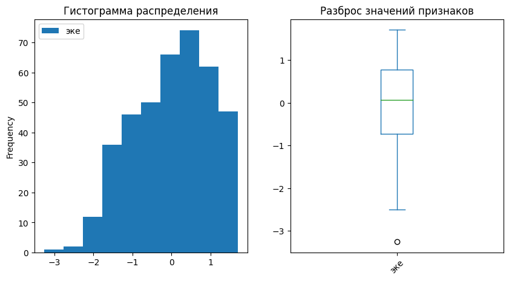

```python
# для количественных признаков тренировочного датасета построим гистограмму частотности распределения и ящик с усами
fig, axes = plt.subplots(nrows=1, ncols=2, figsize=(10,5))

X_train_scaled.plot(kind='hist', bins=10, ax=axes[0])
axes[0].set_title('Гистограмма распределения')
X_train_scaled.plot(kind='box', ax=axes[1], rot=45)
axes[1].set_title('Разброс значений признаков')
plt.show()
```

Обучим модель линейной регрессии на подготовленных данных:

```python
# инициализируем модель линейной регрессии
model_lr = LinearRegression()

# обучим модель на тренировочных данных
model_lr.fit(X_train, y_train)

# получим предсказание модели на тестовых данных
predictions = model_lr.predict(X_test)

# выведем второе предсказанное значение из переменной predictions
# а также известное значение из переменной y_test
predictions[1], y_test.reset_index(drop=True)[1]
```

```
(6147.919240277617, 6547)
```

- Модель ошиблась на **400 кг**. Предсказала удой в **6 147.9 кг**, хотя реальное значение составляет **6 547 кг**.

Оценим качество модели на тестовой выборке. Рассчитаем R²:

```python
# рассчитаем r2 с помощью метода r2_score()
r2 = r2_score(y_test, predictions)

# проверим результат
r2
```

```
0.7307623627127056
```

- Согласно коэффициенту детерминации, в **73 %** случаев предсказание модели ближе к истине, чем среднее значение целевого признака. Значение относительно близко к единице, модель неплохо справляется с предсказанием целевого признака.

Проверим, насколько хорошо модель замечает взаимосвязи между признаками.Проанализируем остатки: рассчитаем остатки и построим гистограмму их распределения, оценим разброс дисперсии остатков на диаграмме рассеивания.

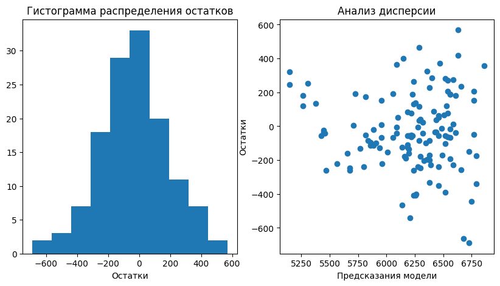

```python
# рассчитаем остатки
residuals = y_test - predictions

# построим графики по количественным признакам - гистограмму частотности распределения
# а также диаграмму рассеяния
fig, axes = plt.subplots(nrows=1, ncols=2, figsize=(10,5))
axes[0].hist(residuals)
axes[0].set_title('Гистограмма распределения остатков')
axes[0].set_xlabel('Остатки')

axes[1].scatter(predictions, residuals)
axes[1].set_xlabel('Предсказания модели')
axes[1].set_ylabel('Остатки')
axes[1].set_title('Анализ дисперсии')

plt.show()
```

- График симметричен относительно **0**. Значит, среднее значение остатков модели равно **0**.
- На диаграмме рассеяния видны очертания "рупора". На одном участке разброс значений остатков сильно больше, чем на другом. Прогнозным значениям модели в области от **5250** до **6000** соответствует разброс остатков модели приблизительно от **-300** до **350**, а в области от **6000** до **6750** — приблизительно от **-750** до **600**.

**Выводы:**

- В связи с чередованием низкой и высокой дисперсии отсатков нежелательно использовать модель в работе. Требуются дополнительные исследования.
- Можно найти и добавить в модель дополнительные признаки из другого датафрейма.
- Можно трансформировать данные, чтобы изменить взаимосвязь входных признаков с целевым.

### Обучение второй модели линейной регресии

Подготовим данные с учетом связи входных признаков с целевым и обучим на них вторую модель `LinearRegression`.

На диаграммах рассеяния можно увидеть, что некоторые входные признаки связаны с целевым нелинейно. Исключим нелинейность, чтобы эти признаки были информативны для линейной регрессии.

`СПО` и `Удой` связаны нелинейно. Чтобы устранить нелинейность, преобразуем `СПО` в категориальный бинарный признак, использовав границу между двумя кластерами на диаграмме — **0.91**:

```python
# преобразуем значения в столбце в категориальный бинарный признак
good_ferma_main['кат_спо'] = (good_ferma_main['спо'] >= 0.91).astype(int)
```

Мы обнаружили, что `ЭКЕ` и `удой` также связаны нелинейно. Исключим нелинейность, введём новый признак `ЭКЕ в квадрате`:

```python
# возведём эке в квадрат и добавим новый признак в таблицу
good_ferma_main['эке_в_квадрате'] = good_ferma_main['эке'] ** 2
```

Также исключим нелинейность между `сырой_протеин_г` и `удой_кг`:

```python
# возведём эке в квадрат и добавим новый признак в таблицу
good_ferma_main['сырой_протеин_в_квадрате'] = good_ferma_main['сырой_протеин_г'] ** 2
```

Подготовим данные и обучим модель:

```python
# выделим входные и целевой признаки и сохраним их в переменные
X_2 = good_ferma_main[['кат_спо', 'эке_в_квадрате', 'сырой_протеин_в_квадрате', 'порода_папы_быка', 'возраст']]
y_2 = good_ferma_main['удой_кг']

# разделим датафрейм на тренировочную и тестовую выборки
X_train_2, X_test_2, y_train_2, y_test_2 = train_test_split(
    X_2,
    y_2,
    random_state = RANDOM_STATE
)

# сохраним в переменную количественные признаки
num_col_names_2 = ['эке_в_квадрате', 'сырой_протеин_в_квадрате']

# отмасштабируем числовые признаки с помощью стандартизации
scaler = StandardScaler()
X_train_scaled_2 = scaler.fit_transform(X_train_2[num_col_names_2])
X_test_scaled_2 = scaler.transform(X_test_2[num_col_names_2])

# закодируем категориальные признаки
encoder = OneHotEncoder(drop='first', sparse_output=False)
X_train_ohe_2 = encoder.fit_transform(X_train_2[['кат_спо', 'порода_папы_быка', 'возраст']])
X_test_ohe_2 = encoder.transform(X_test_2[['кат_спо', 'порода_папы_быка', 'возраст']])

encoder_col_names = encoder.get_feature_names_out()

# создадим тренировочный и тестовый датафреймы из закодированных и отмасштабированных данных
X_train_ohe_2 = pd.DataFrame(X_train_ohe_2, columns=encoder_col_names, index=X_train_2.index)
X_test_ohe_2 = pd.DataFrame(X_test_ohe_2, columns=encoder_col_names, index=X_test_2.index)

X_train_scaled_2 = pd.DataFrame(X_train_scaled_2, columns=num_col_names_2, index=X_train_2.index)
X_test_scaled_2 = pd.DataFrame(X_test_scaled_2, columns=num_col_names_2, index=X_test_2.index)

# объединим все преобразованные данные в тренировочный и тестовый датафреймы
X_train_final_2 = pd.concat([X_train_ohe_2, X_train_scaled_2], axis=1)
X_test_final_2 = pd.concat([X_test_ohe_2, X_test_scaled_2], axis=1)

# инициализируем модель линейной регрессии и обучим её
model_lr_2 = LinearRegression()
model_lr_2.fit(X_train_final_2, y_train_2)

# получим предсказание модели на тестовых данных
predictions_2 = model_lr_2.predict(X_test_final_2)

predictions_2[1], y_test_2.reset_index(drop=True)[1]
```

```
(6430.723741039567, 6547)
```

- Вторая модель ошиблась на **116.3 кг**. Предсказала удой в **6 430.7 кг**, в то время как реальное значение составляет **6 547 кг**.

Рассчитаем коэффициент детерминации:

```python
# рассчитаем r2
r2_2 = r2_score(y_test_2, predictions_2)

# выведем результат
f"r2_2 = {r2_2:.2f}%"
```

```
'r2_2 = 0.78%'
```

- Коэффициент детерминации увеличился на **5%** по сравнению с расчётами для первой модели и составляет **78 %**.

Проанализируем остатки:

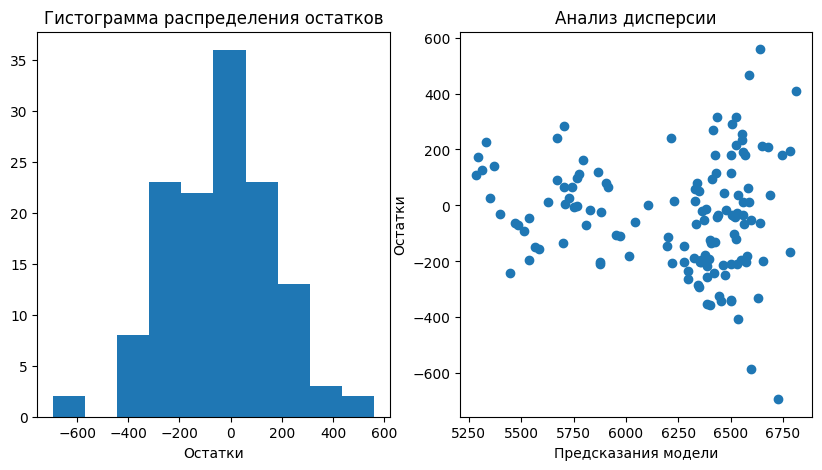

```python
# рассчитаем остатки
residuals_2 = y_test_2 - predictions_2

# построим графики по количественным признакам - гистограмму частотности распределения
# а также диаграмму рассеяния
fig, axes = plt.subplots(nrows=1, ncols=2, figsize=(10,5))
axes[0].hist(residuals_2)
axes[0].set_title('Гистограмма распределения остатков')
axes[0].set_xlabel('Остатки')

axes[1].scatter(predictions_2, residuals_2)
axes[1].set_xlabel('Предсказания модели')
axes[1].set_ylabel('Остатки')
axes[1].set_title('Анализ дисперсии')

plt.show()
```

- Гистограмма распределения остатков для второй модели по-прежнему симметрична относительно **0**. Среднее значение остатков модели равно **0**.
- На диаграмме рассеяния для второй модели "рупор" стал более чётким.

**Выводы:**

- С одной стороны, предсказание второй модели стало более точным по сравнению с первой моделю и увеличился процент коэффициента детерминации, с другой стороны — диаграмма рассеяния по-прежнему показывает чередование низкой и высокой дисперсии отсатков. Чётче вырисовывается "рупор".

Для корректной работы модели требуются дополнительные исследования.

### Обучение третьей модели линейной регрессии

Добавим в данные новый признак и обучим на них третью модель `LinearRegression`.

Добавим признак `имя_папы` из файла `ferma_dad.csv`. Соединим его с остальными данными в `good_ferma_main` по ключу.

Выведем размерность датафреймов до объединения:

```python
# выведем размерность с помощью shape
ferma_dad.shape
```

```
(629, 2)
```

```python
# выведем размерность с помощью shape
good_ferma_main.shape
```

```
(528, 15)
```

Объединим датафреймы:

```python
# содединим данные с помощью merge()
good_ferma_main = good_ferma_main.merge(ferma_dad, on='id', how='left')

# проверим рещультат
good_ferma_main.head()
```

|  | id | удой_кг | эке | сырой_протеин_г | спо | порода | тип_пастбища | порода_папы_быка | жирность_% | белок_% | вкус_молока | возраст | кат_спо | эке_в_квадрате | сырой_протеин_в_квадрате | имя_папы |
| --- | --- | --- | --- | --- | --- | --- | --- | --- | --- | --- | --- | --- | --- | --- | --- | --- |
| 0 | 1 | 5863 | 14.2 | 1743 | 0.890 | Вис Бик Айдиал | равнинное | Айдиал | 3.58 | 3.076 | вкусно | более_2_лет | 0 | 201.64 | 3038049 | Буйный |
| 1 | 2 | 5529 | 12.8 | 2138 | 0.890 | Вис Бик Айдиал | равнинное | Соверин | 3.54 | 3.079 | вкусно | менее_2_лет | 0 | 163.84 | 4571044 | Соловчик |
| 2 | 3 | 5810 | 14.0 | 1854 | 0.885 | РефлешнСоверинг | холмистое | Соверин | 3.59 | 3.074 | не вкусно | более_2_лет | 0 | 196.00 | 3437316 | Барин |
| 3 | 4 | 5895 | 12.4 | 2012 | 0.885 | РефлешнСоверинг | холмистое | Айдиал | 3.40 | 3.075 | не вкусно | более_2_лет | 0 | 153.76 | 4048144 | Буйный |
| 4 | 5 | 5302 | 12.8 | 1675 | 0.885 | Вис Бик Айдиал | равнинное | Соверин | 3.73 | 3.073 | вкусно | менее_2_лет | 0 | 163.84 | 2805625 | Барин |

Проверим размерность после объединения:

```python
# проверим размерность с помощью shape
good_ferma_main.shape
```

```
(528, 16)
```

Объединение прошло успешно.

Устраним нелинейность между целевым признаком `удой_кг` и новым входным `имя_папы` с помощью `OneHotEncoding`. Переведём категориальный признак `имя_папы` в бинарные столбцы. Затем обучим модель и оценим её качество:

```python
# выделим входные признаки и целевой признак
X_3 = good_ferma_main[['кат_спо', 'эке_в_квадрате', 'сырой_протеин_в_квадрате', 'порода_папы_быка', 'возраст', 'имя_папы']]
y_3 = good_ferma_main['удой_кг']

# разделим датафрейм на тренировочную и тестовую выборки
X_train_3, X_test_3, y_train_3, y_test_3 = train_test_split(
    X_3,
    y_3,
    random_state = RANDOM_STATE
)

# сохраним в переменную количественные признаки
num_col_names_3 = ['эке_в_квадрате', 'сырой_протеин_в_квадрате']

# отмасштабируем числовые признаки с помощью стандартизации
scaler = StandardScaler()
X_train_scaled_3 = scaler.fit_transform(X_train_3[num_col_names_3])
X_test_scaled_3 = scaler.transform(X_test_3[num_col_names_3])

# закодируем категориальные признаки
encoder = OneHotEncoder(drop='first', sparse_output=False)
X_train_ohe_3 = encoder.fit_transform(X_train_3[['кат_спо', 'порода_папы_быка', 'возраст', 'имя_папы']])
X_test_ohe_3 = encoder.transform(X_test_3[['кат_спо', 'порода_папы_быка', 'возраст', 'имя_папы']])

encoder_col_names = encoder.get_feature_names_out()

# создадим тренировочный и тестовый датафреймы из закодированных и отмасштабированных данных
X_train_ohe_3 = pd.DataFrame(X_train_ohe_3, columns=encoder_col_names, index=X_train_3.index)
X_test_ohe_3 = pd.DataFrame(X_test_ohe_3, columns=encoder_col_names, index=X_test_3.index)
X_train_scaled_3 = pd.DataFrame(X_train_scaled_3, columns=num_col_names_3, index=X_train_3.index)
X_test_scaled_3 = pd.DataFrame(X_test_scaled_3, columns=num_col_names_3, index=X_test_3.index)

# объединим все преобразованные данные в тренировочный и тестовый датафреймы
X_train_final_3 = pd.concat([X_train_ohe_3, X_train_scaled_3], axis=1)
X_test_final_3 = pd.concat([X_test_ohe_3, X_test_scaled_3], axis=1)

# инициализируем модель линейной регрессии и обучим её
model_lr_3 = LinearRegression()
model_lr_3.fit(X_train_final_3, y_train_3)

# получим предсказание модели на тестовых данных
predictions_3 = model_lr_3.predict(X_test_final_3)

predictions_3[1], y_test_3.reset_index(drop=True)[1]
```

```
(6470.426121429657, 6547)
```

- Третья модель ошиблась на **76.6 кг**. Предсказала удой в **6 470.4 кг**, в то время как известное значение составляет **6 547 кг**.

Оценим качество модели на тестовой выборке. Рассчитаем R²:

```python
# рассчитаем r2
r2_3 = r2_score(y_test_3, predictions_3)

# выведем результат
f"r2_3 = {r2_3:.2f}%"
```

```
'r2_3 = 0.79%'
```

- Коэффициент детерминации увеличился на **1%** по сравнению с расчётами для второй модели и составляет **79 %**.

Проанализируем остатки:

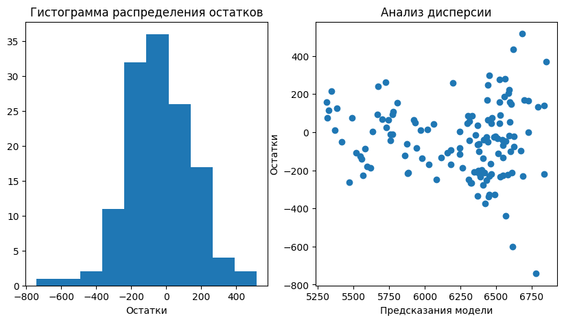

```python
# рассчитаем остатки
residuals_3 = y_test_3 - predictions_3

# построим графики по количественным признакам - гистограмму частотности распределения
# а также диаграмму рассеяния
fig, axes = plt.subplots(nrows=1, ncols=2, figsize=(10,5))
axes[0].hist(residuals_3)
axes[0].set_title('Гистограмма распределения остатков')
axes[0].set_xlabel('Остатки')

axes[1].scatter(predictions_3, residuals_3)
axes[1].set_xlabel('Предсказания модели')
axes[1].set_ylabel('Остатки')
axes[1].set_title('Анализ дисперсии')

plt.show()
```

- Гистограмма распределения остатков для третьей модели относительно симметрична, немного перекошена влево.
- На диаграмме рассеяния для третьей модели по-прежнему виден "рупор".

**Выводы:**

- Предсказание третьей модели стало более точным по сравнению со второй моделью. Процент коэффициента детерминации увеличился на **1** %. Тем не менее, на диаграмме рассеяния всё ещё виден "рупор".

Возможно, для корректной работы модели требуются дополнительные данные.

### Сравнение качества трёх моделей линейной регрессии

Сопоставим R² и остатки трёх моделей:

1. R² первой модели составляет **73** %. Среднее значение остатков модели равно **0**. На диаграмме рассеяния видны очертания "рупора". Желательно улучшить качество модели для использования в реальных условиях.
2. R² второй модели составляет **78** %. Гистограмма распределения остатков для второй модели по-прежнему симметрична относительно **0**. На диаграмме рассеяния для второй модели "рупор" стал более чётким.
3. R² третьей модели составляет **79** %. Гистограмма распределения остатков для третьей модели относительно симметрична. На диаграмме рассеяния по-прежнему виден "рупор".

Оценим качество каждой модели по трём метрикам: `MSE`, `MAE`, `RMSE`.

C помощью функции рассчитаем метрику `MSE` для каждой модели:

```python
# рассчитаем MSE первой модели
mse_1 = mean_squared_error(y_test, predictions)

# рассчитаем MSE второй модели
mse_2 = mean_squared_error(y_test_2, predictions_2)

# рассчитаем MSE третьей модели
mse_3 = mean_squared_error(y_test_3, predictions_3)

# выводим результат с помощью print(), чтобы отобразился перенос строк
print(f"""MSE первой модели = {mse_1:.1f}
MSE второй модели = {mse_2:.1f}
MSE третьей модели = {mse_3:.1f}""")
```

```
MSE первой модели = 50769.9
MSE второй модели = 41039.4
MSE третьей модели = 38734.0
```

Извлечём корень из `MSE`, чтобы получить `RMSE` для каждой модели и привести значения к единицам целевого признака:

```python
# извлечём корень из MSE с помощью параметра squared=False
rmse_1 = np.sqrt(mean_squared_error(y_test, predictions))

rmse_2 = np.sqrt(mean_squared_error(y_test_2, predictions_2))

rmse_3 = np.sqrt(mean_squared_error(y_test_3, predictions_3))

# выводим результат с помощью print(), чтобы отобразился перенос строк
print(f"""RMSE первой модели = {rmse_1:.1f}
RMSE второй модели = {rmse_2:.1f}
RMSE третьей модели = {rmse_3:.1f}""")
```

```
RMSE первой модели = 225.3
RMSE второй модели = 202.6
RMSE третьей модели = 196.8
```

- Согласно корню среднеквадратичной ошибки, в среднем третья модель ошибается примерно на **196.8** кг. То есть, на **28.5** кг меньше, чем первая модель и на **5.8** кг меньше, чем вторая.

C помощью функции рассчитаем метрику `MAE` для каждой модели:

```python
# рассчитаем MAE первой модели
mae_1 = mean_absolute_error(y_test, predictions)

# рассчитаем MAE второй модели
mae_2 = mean_absolute_error(y_test_2, predictions_2)

# рассчитаем MAE третьей модели
mae_3 = mean_absolute_error(y_test_3, predictions_3)

# выводим результат с помощью print(), чтобы отобразился перенос строк
print(f"""MAE первой модели = {mae_1:.1f}
MAE второй модели = {mae_2:.1f}
MAE третьей модели = {mae_3:.1f}""")
```

```
MAE первой модели = 177.6
MAE второй модели = 160.0
MAE третьей модели = 154.7
```

- Согласно средней абсолютной ошибке, в среднем третья модель отклоняется от истинного значения целевого признака в меньшей степени, чем первая и вторая — на ≈**154** кг.

Так как мы предварительно очистили датафрейм `good_ferma_main` от выбросов, выберем метрику оценки модели `RMSE`. Согласно корню среднеквадратичной ошибки, третья модель более эффективна, чем первая и вторая.

Несмотря на наличие "рупора" на диаграмме рассеяния, третья модель показывает лучшие значения в результате расчёта метрик `R²`, `MAE`, `MSE` и `RMSE`. Выберем третью модель для дальнейшего использования.

Укажем доверительный интервал прогноза лучшей модели. Для этого рассчитаем квантили ошибки модели на тренировочных данных:

```python
# посчитаем ошибки на обучении
train_pred_3 = model_lr_3.predict(X_train_final_3)
train_pred_error_3 = y_train_3 - train_pred_3

# вычислим квантили ошибки на тренировочных данных
lower_quantile = np.percentile(train_pred_error_3, 2.5)
upper_quantile = np.percentile(train_pred_error_3, 97.5)

# получим предсказания на тестовых данных
test_pred_3 = model_lr_3.predict(X_test_final_3)

# построим доверительный интервал
lower_bound = test_pred_3 + lower_quantile
upper_bound = test_pred_3 + upper_quantile

# покажем прогноз с доверительным интервалом
print(f"""Предсказание: {test_pred_3[1]:.2f}
Доверительный интервал: ({lower_bound[1]:.2f}, {upper_bound[1]:.2f})""")
```

```
Предсказание: 6470.43
Доверительный интервал: (6132.40, 6831.65)
```

С помощью лучшей модели спрогнозируем удой коров, которых хочет купить фермер.

Добавим недостающие признаки `эке`, `сырой_протеин_г` и `спо` в датафрейм `cow_buy.csv`. Возьмём из датасета `ferma_main.csv` средние значения каждого из признаков и увеличим их на 5%:

```python
# рассчитаем средние значения по нужным признакам
mean_eke = good_ferma_main['эке'].mean()
mean_spo = good_ferma_main['спо'].mean()
mean_protein = good_ferma_main['сырой_протеин_г'].mean()

# увеличим средние значения каждого признака на 5%
mean_eke *= 1.05
mean_spo *= 1.05
mean_protein *= 1.05

# добавим недостающие признаки в датафрейм cow_buy
cow_buy['эке'] = mean_eke
cow_buy['спо'] = mean_spo
cow_buy['сырой_протеин_г'] = mean_protein

# проверим результат
cow_buy.head()
```

|  | порода | тип_пастбища | порода_папы_быка | имя_папы | текущая_жирность_% | текущий_уровень_белок_% | возраст | эке | спо | сырой_протеин_г |
| --- | --- | --- | --- | --- | --- | --- | --- | --- | --- | --- |
| 0 | Вис Бик Айдиал | холмистое | Айдиал | Геркулес | 3.58 | 3.076 | более_2_лет | 15.513949 | 0.964479 | 2039.360511 |
| 1 | Вис Бик Айдиал | равнинное | Соверин | Буйный | 3.54 | 3.081 | менее_2_лет | 15.513949 | 0.964479 | 2039.360511 |
| 2 | РефлешнСоверинг | равнинное | Соверин | Барин | 3.59 | 3.074 | более_2_лет | 15.513949 | 0.964479 | 2039.360511 |
| 3 | РефлешнСоверинг | холмистое | Айдиал | Буйный | 3.40 | 3.061 | более_2_лет | 15.513949 | 0.964479 | 2039.360511 |
| 4 | РефлешнСоверинг | равнинное | Айдиал | Буйный | 3.64 | 3.074 | более_2_лет | 15.513949 | 0.964479 | 2039.360511 |

Подготовим признаки перед обучением модели.

Преобразуем `спо` в категориальный бинарный признак:

```python
# преобразуем значения в столбце в категориальный бинарный признак
cow_buy['кат_спо'] = (cow_buy['спо'] >= 0.91).astype(int)
```

Возведём признак `эке` в квадрат:

```python
# возведём эке в квадрат и добавим новый признак в таблицу
cow_buy['эке_в_квадрате'] = cow_buy['эке'] ** 2
```

Исключим нелинейность между `сырой_протеин_г` и `удой_кг`:

```python
# возведём эке в квадрат и добавим новый признак в таблицу
cow_buy['сырой_протеин_в_квадрате'] = cow_buy['сырой_протеин_г'] ** 2
```

```python
# проверим результат
cow_buy.head()
```

|  | порода | тип_пастбища | порода_папы_быка | имя_папы | текущая_жирность_% | текущий_уровень_белок_% | возраст | эке | спо | сырой_протеин_г | кат_спо | эке_в_квадрате | сырой_протеин_в_квадрате |
| --- | --- | --- | --- | --- | --- | --- | --- | --- | --- | --- | --- | --- | --- |
| 0 | Вис Бик Айдиал | холмистое | Айдиал | Геркулес | 3.58 | 3.076 | более_2_лет | 15.513949 | 0.964479 | 2039.360511 | 1 | 240.682609 | 4.158991e+06 |
| 1 | Вис Бик Айдиал | равнинное | Соверин | Буйный | 3.54 | 3.081 | менее_2_лет | 15.513949 | 0.964479 | 2039.360511 | 1 | 240.682609 | 4.158991e+06 |
| 2 | РефлешнСоверинг | равнинное | Соверин | Барин | 3.59 | 3.074 | более_2_лет | 15.513949 | 0.964479 | 2039.360511 | 1 | 240.682609 | 4.158991e+06 |
| 3 | РефлешнСоверинг | холмистое | Айдиал | Буйный | 3.40 | 3.061 | более_2_лет | 15.513949 | 0.964479 | 2039.360511 | 1 | 240.682609 | 4.158991e+06 |
| 4 | РефлешнСоверинг | равнинное | Айдиал | Буйный | 3.64 | 3.074 | более_2_лет | 15.513949 | 0.964479 | 2039.360511 | 1 | 240.682609 | 4.158991e+06 |

Выполним подготовку данных и получим прогноз удоя коров с помощью третьей модели:

```python
# сохраним в переменную количественные признаки
final_num_col_names = ['эке_в_квадрате', 'сырой_протеин_в_квадрате']

# отмасштабируем числовые признаки
cow_buy_scaled = scaler.transform(cow_buy[final_num_col_names])
cow_buy_scaled = pd.DataFrame(cow_buy_scaled, columns = final_num_col_names, index=cow_buy.index)

# закодируем категориальные признаки
cow_buy_ohe = encoder.transform(cow_buy[['кат_спо', 'порода_папы_быка', 'возраст', 'имя_папы']])
cow_buy_ohe = pd.DataFrame(cow_buy_ohe, columns=encoder_col_names, index=cow_buy.index)

# объединим данные
cow_buy_final = pd.concat([cow_buy_ohe, cow_buy_scaled], axis=1)

# получим прогноз
cow_buy_predictions = model_lr_3.predict(cow_buy_final)

# выведем результат
f'Прогноз удоя коров = {cow_buy_predictions[1]:.1f}'
```

```
'Прогноз удоя коров = 6461.3'
```

Добавим прогноз удоя коров «ЭкоФермы» в датафрейм с коровами, покупку которых рассматривает фермер:

```python
# добавим прогноз в новый столбец датафрейма
cow_buy['прогноз_удоя'] = cow_buy_predictions

# проверим результат, отсортируем значения в столбце 'прогноз_удоя' по убыванию
cow_buy.sort_values(by='прогноз_удоя', ascending=False)
```

|  | порода | тип_пастбища | порода_папы_быка | имя_папы | текущая_жирность_% | текущий_уровень_белок_% | возраст | эке | спо | сырой_протеин_г | кат_спо | эке_в_квадрате | сырой_протеин_в_квадрате | прогноз_удоя |
| --- | --- | --- | --- | --- | --- | --- | --- | --- | --- | --- | --- | --- | --- | --- |
| 7 | Вис Бик Айдиал | равнинное | Соверин | Буйный | 3.57 | 3.079 | более_2_лет | 15.513949 | 0.964479 | 2039.360511 | 1 | 240.682609 | 4.158991e+06 | 6638.299793 |
| 18 | Вис Бик Айдиал | равнинное | Соверин | Буйный | 3.34 | 3.069 | более_2_лет | 15.513949 | 0.964479 | 2039.360511 | 1 | 240.682609 | 4.158991e+06 | 6638.299793 |
| 3 | РефлешнСоверинг | холмистое | Айдиал | Буйный | 3.40 | 3.061 | более_2_лет | 15.513949 | 0.964479 | 2039.360511 | 1 | 240.682609 | 4.158991e+06 | 6629.944088 |
| 4 | РефлешнСоверинг | равнинное | Айдиал | Буйный | 3.64 | 3.074 | более_2_лет | 15.513949 | 0.964479 | 2039.360511 | 1 | 240.682609 | 4.158991e+06 | 6629.944088 |
| 15 | РефлешнСоверинг | холмистое | Айдиал | Буйный | 3.40 | 3.065 | более_2_лет | 15.513949 | 0.964479 | 2039.360511 | 1 | 240.682609 | 4.158991e+06 | 6629.944088 |
| 11 | РефлешнСоверинг | равнинное | Соверин | Геркулес | 3.73 | 3.073 | более_2_лет | 15.513949 | 0.964479 | 2039.360511 | 1 | 240.682609 | 4.158991e+06 | 6624.400964 |
| 0 | Вис Бик Айдиал | холмистое | Айдиал | Геркулес | 3.58 | 3.076 | более_2_лет | 15.513949 | 0.964479 | 2039.360511 | 1 | 240.682609 | 4.158991e+06 | 6616.045259 |
| 12 | Вис Бик Айдиал | холмистое | Айдиал | Геркулес | 3.68 | 3.046 | более_2_лет | 15.513949 | 0.964479 | 2039.360511 | 1 | 240.682609 | 4.158991e+06 | 6616.045259 |
| 1 | Вис Бик Айдиал | равнинное | Соверин | Буйный | 3.54 | 3.081 | менее_2_лет | 15.513949 | 0.964479 | 2039.360511 | 1 | 240.682609 | 4.158991e+06 | 6461.276496 |
| 9 | РефлешнСоверинг | холмистое | Айдиал | Буйный | 3.40 | 3.079 | менее_2_лет | 15.513949 | 0.964479 | 2039.360511 | 1 | 240.682609 | 4.158991e+06 | 6452.920791 |
| 5 | РефлешнСоверинг | равнинное | Соверин | Геркулес | 3.63 | 3.053 | менее_2_лет | 15.513949 | 0.964479 | 2039.360511 | 1 | 240.682609 | 4.158991e+06 | 6447.377668 |
| 17 | РефлешнСоверинг | равнинное | Соверин | Геркулес | 3.77 | 3.053 | менее_2_лет | 15.513949 | 0.964479 | 2039.360511 | 1 | 240.682609 | 4.158991e+06 | 6447.377668 |
| 10 | Вис Бик Айдиал | холмистое | Соверин | Соловчик | 3.73 | 3.055 | более_2_лет | 15.513949 | 0.964479 | 2039.360511 | 1 | 240.682609 | 4.158991e+06 | 6360.163370 |
| 16 | Вис Бик Айдиал | холмистое | Соверин | Соловчик | 3.73 | 3.079 | более_2_лет | 15.513949 | 0.964479 | 2039.360511 | 1 | 240.682609 | 4.158991e+06 | 6360.163370 |
| 2 | РефлешнСоверинг | равнинное | Соверин | Барин | 3.59 | 3.074 | более_2_лет | 15.513949 | 0.964479 | 2039.360511 | 1 | 240.682609 | 4.158991e+06 | 6342.990289 |
| 13 | Вис Бик Айдиал | холмистое | Соверин | Барин | 3.42 | 3.075 | менее_2_лет | 15.513949 | 0.964479 | 2039.360511 | 1 | 240.682609 | 4.158991e+06 | 6165.966992 |

## Обучение логистической регрессии

Подготовим данные датасета `good_ferma_main` и обучим на них модель `LogisticRegression`. Используем в качестве целевого признак `вкус_молока`.

```python
# создадим константу RANDOM_STATE
RANDOM_STATE = 42

# выделим входные и целевой признаки
X_4 = good_ferma_main.drop(columns='вкус_молока')
y_4 = good_ferma_main['вкус_молока']

# определим категориальные и числовые признаки
num_features = ['эке_в_квадрате', 'сырой_протеин_в_квадрате']
cat_features = ['кат_спо', 'порода_папы_быка', 'возраст', 'порода', 'имя_папы', 'тип_пастбища']

# разобьём данные на тренировочную и тестовую выборки
X_train_4, X_test_4, y_train_4, y_test_4 = train_test_split(
    X_4,
    y_4,
    random_state=RANDOM_STATE
)

# приведём значения всех признаков к единой шкале
scaler = StandardScaler()
X_train_scaled_4 = scaler.fit_transform(X_train_4[num_features])
X_test_scaled_4 = scaler.transform(X_test_4[num_features])

X_train_scaled_4 = pd.DataFrame(X_train_scaled_4, columns=num_features, index=X_train_4.index)
X_test_scaled_4 = pd.DataFrame(X_test_scaled_4, columns=num_features, index=X_test_4.index)

# закодируем категориальные признаки
encoder = OneHotEncoder(drop='first', sparse_output=False)
X_train_encoded_4 = encoder.fit_transform(X_train_4[cat_features])
X_test_encoded_4 = encoder.transform(X_test_4[cat_features])

# получим имена новых колонок после кодирования
encoder_col_names = encoder.get_feature_names_out()

X_train_encoded_4 = pd.DataFrame(X_train_encoded_4, columns=encoder_col_names, index=X_train_4.index)
X_test_encoded_4 = pd.DataFrame(X_test_encoded_4, columns=encoder_col_names, index=X_test_4.index)

# объединим числовые и категориальные признаки
X_train_final_4 = pd.concat([X_train_scaled_4, X_train_encoded_4], axis=1)
X_test_final_4 = pd.concat([X_test_scaled_4, X_test_encoded_4], axis=1)

# инициализируем LogisticRegression
clf = LogisticRegression()

# обучим модель и получим предсказание
clf.fit(X_train_final_4, y_train_4)
y_pred = clf.predict(X_test_final_4)

y_pred[1], y_test_4.reset_index(drop=True)[1]
```

```
('вкусно', 'вкусно')
```

Оценим качество модели на тестовой выборке: рассчитаем метрики `accuracy`, `recall`, `precision`.

Оценим качество модели по метрике accuracy:

```python
# рассчитаем ассuracy
acc = accuracy_score(y_test_4, y_pred)

# выведем результат
f'Точность модели = {round(acc, 3)}'
```

```
'Точность модели = 0.667'
```

Модель ошибается почти в 33% случаев.

Рассчитаем recall и precision:

```python
# рассчитаем recall с помощью recall_score()
# укажем какой класс считать позитивным с помощью параметра pos_label
recall = recall_score(y_test_4, y_pred, pos_label='вкусно')

# выведем результат
f'recall = {round(recall, 3)}'
```

```
'recall = 0.782'
```

```python
# рассчитаем precision с помощью precision_score()
# укажем, какой класс считать позитивным с помощью параметра pos_label
precision = precision_score(y_test_4, y_pred, pos_label='вкусно')

f'precision = {round(precision, 3)}'
```

```
'precision = 0.731'
```

- `Recall` выше, чем `precision`. Модель чаще совершает ошибки типа **False Positive**, чем **False Negative**. Это значит, что модель чаще ошибочно относит молоко к категории `вкусно`.

Построим матрицу ошибок.

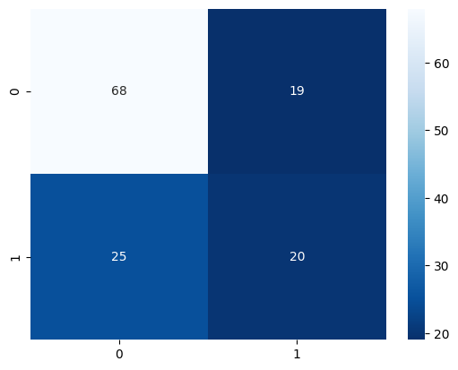

```python
# построим матрицу ошибок с помощью confusion_matrix()
cm = confusion_matrix(y_test_4, y_pred)

# выведем результат в виде тепловой карты
sns.heatmap(cm, annot=True, fmt='d', cmap='Blues_r')
```

Можно предположить, что при покупке коров критичнее всего ошибка первого рода, когда модель чаще ошибочно относит невкусное молоко к категории вкусного. Для заказчика главное - вкусное молоко. В этом случае, важнее метрика `precision`, так как она проверяет, не слишком ли часто модель выставляет класс 1 объектам класса 0.

```python
# получим вероятности принадлежности к позитивному классу
y_proba = clf.predict_proba(X_test_final_4)[:,1]

# подготовим таблицу с результатом
data = pd.DataFrame(zip(y_test_4, y_proba),
                   columns=['y_valid', 'y_proba']).sort_values(by='y_proba', ascending=False)

# выведем 5 первых строк, отсортированных по убыванию
data.head()
```

|  | y_valid | y_proba |
| --- | --- | --- |
| 117 | вкусно | 0.777720 |
| 87 | вкусно | 0.730001 |
| 69 | вкусно | 0.706400 |
| 86 | не вкусно | 0.705968 |
| 2 | вкусно | 0.693640 |

Посмотрим, как модель будет работать при 10 разных порогах. Укажем в `linspace` промежуток пороговых значений — `0.1 - 1.0`:

```python
# укажем в linspace промежуток пороговых значений
thresholds = [round(i,2) for i in np.linspace(0.1,1.0,num = 10, endpoint=False)]

# выведем результат
thresholds
```

```
[0.1, 0.19, 0.28, 0.37, 0.46, 0.55, 0.64, 0.73, 0.82, 0.91]
```

Создадим расчётные столбцы с предсказаниями для каждого порога и добавим их в таблицу при помощи lambda-функции:

```python
# создадим переменную, которая будет хранить список новых колонок
columns = []

# добавим столбцы с новыми предсказаниями в таблицу
for i in thresholds:
    columns.append('y_pred'+str(i))
    data['y_pred'+str(i)] = data['y_proba'].apply(lambda x: 1 if x >= i else 0)

# выведем 5 случайных строк
data.sample(5)
```

|  | y_valid | y_proba | y_pred0.1 | y_pred0.19 | y_pred0.28 | y_pred0.37 | y_pred0.46 | y_pred0.55 | y_pred0.64 | y_pred0.73 | y_pred0.82 | y_pred0.91 |
| --- | --- | --- | --- | --- | --- | --- | --- | --- | --- | --- | --- | --- |
| 0 | вкусно | 0.490681 | 1 | 1 | 1 | 1 | 1 | 0 | 0 | 0 | 0 | 0 |
| 116 | не вкусно | 0.483113 | 1 | 1 | 1 | 1 | 1 | 0 | 0 | 0 | 0 | 0 |
| 53 | не вкусно | 0.292801 | 1 | 1 | 1 | 0 | 0 | 0 | 0 | 0 | 0 | 0 |
| 17 | вкусно | 0.437512 | 1 | 1 | 1 | 1 | 0 | 0 | 0 | 0 | 0 | 0 |
| 126 | не вкусно | 0.546911 | 1 | 1 | 1 | 1 | 1 | 0 | 0 | 0 | 0 | 0 |

Переведём значения **вкусно** и **не вкусно** в `y_valid` в числа **0** и **1**:

```python
# переведём значения в числа
data['y_valid_num'] = data['y_valid'].apply(lambda x: 1 if x == 'вкусно' else 0)

# проверим результат
data.head()
```

|  | y_valid | y_proba | y_pred0.1 | y_pred0.19 | y_pred0.28 | y_pred0.37 | y_pred0.46 | y_pred0.55 | y_pred0.64 | y_pred0.73 | y_pred0.82 | y_pred0.91 | y_valid_num |
| --- | --- | --- | --- | --- | --- | --- | --- | --- | --- | --- | --- | --- | --- |
| 117 | вкусно | 0.777720 | 1 | 1 | 1 | 1 | 1 | 1 | 1 | 1 | 0 | 0 | 1 |
| 87 | вкусно | 0.730001 | 1 | 1 | 1 | 1 | 1 | 1 | 1 | 1 | 0 | 0 | 1 |
| 69 | вкусно | 0.706400 | 1 | 1 | 1 | 1 | 1 | 1 | 1 | 0 | 0 | 0 | 1 |
| 86 | не вкусно | 0.705968 | 1 | 1 | 1 | 1 | 1 | 1 | 1 | 0 | 0 | 0 | 0 |
| 2 | вкусно | 0.693640 | 1 | 1 | 1 | 1 | 1 | 1 | 1 | 0 | 0 | 0 | 1 |

Посчитаем метрики для каждого порога:

```python
# посчитаем метрики для каждого порога с помощью цикла
for col in columns:
    recall = recall_score(data['y_valid_num'], data[col])
    precision = precision_score(data['y_valid_num'], data[col])
    print(f'Порог {col[-4:]}: Recall = {round(recall, 3)}, Precision = {round(precision, 3)}')
```

```
Порог d0.1: Recall = 1.0, Precision = 0.659
Порог 0.19: Recall = 0.954, Precision = 0.648
Порог 0.28: Recall = 0.713, Precision = 0.585
Порог 0.37: Recall = 0.529, Precision = 0.561
Порог 0.46: Recall = 0.356, Precision = 0.554
Порог 0.55: Recall = 0.172, Precision = 0.484
Порог 0.64: Recall = 0.092, Precision = 0.8
Порог 0.73: Recall = 0.023, Precision = 1.0
Порог 0.82: Recall = 0.0, Precision = 0.0
Порог 0.91: Recall = 0.0, Precision = 0.0
```

```python
# переведём вероятности в предсказания по новому порогу
threshold_037 = 0.37
y_pred_new = (y_proba >= threshold_037).astype(int)

# переведём y_test_4 в 0 и 1
y_test_bin = (y_test_4 == 'вкусно').astype(int)

# рассчитаем метрики
recall_new = recall_score(y_test_bin, y_pred_new)
precision_new = precision_score(y_test_bin, y_pred_new)
```

```python
# выведем recall
f'Recall при пороге {threshold_037} = {round(recall_new, 3)}'
```

```
'Recall при пороге 0.37 = 0.529'
```

```python
# выведем precision
f'Precision при пороге {threshold_037} = {round(precision_new, 3)}'
```

```
'Precision при пороге 0.37 = 0.561'
```

С помощью обученной модели спрогнозируем вкус молока коров, которых фермер хочет купить. Используем новые данные, которые находятся в датасете `cow_buy.csv`. Выполним подготовку данных и получим прогноз вкуса молока коров:

```python
# сохраним в переменные категориальные и числовые признаки
num_features_5 = ['эке_в_квадрате', 'сырой_протеин_в_квадрате']
cat_features_5 = ['кат_спо', 'порода_папы_быка', 'возраст', 'порода', 'имя_папы','тип_пастбища']

# отмасштабируем числовые признаки
real_cow_buy_scaled = scaler.transform(cow_buy[num_features_5])
real_cow_buy_scaled = pd.DataFrame(real_cow_buy_scaled, columns=num_features_5, index=cow_buy.index)

# закодируем категориальные признаки
real_cow_buy_encoded = encoder.transform(cow_buy[cat_features_5])
real_cow_buy_encoded = pd.DataFrame(real_cow_buy_encoded, columns=encoder_col_names, index=cow_buy.index)

# соберём данные в датасет
real_final_cow_buy = pd.concat([real_cow_buy_scaled, real_cow_buy_encoded], axis=1)

# предскажем вероятности
y_real_proba = clf.predict_proba(real_final_cow_buy)[:, 1]

# переведём вероятности в предсказания по своему порогу - 0.64
new_threshold = 0.37
y_real_pred = (y_real_proba >= new_threshold).astype(int)

y_real_pred[1]
```

```
0
```

Добавим прогноз вкуса молока коров «ЭкоФермы» в датафрейм с коровами, покупку которых рассматривает фермер:

```python
# добавим новый столбец с прогнозом в таблицу
cow_buy['вкус_молока'] = y_real_pred

# проверим результат, отсортируем столбец вкус_молока по убыванию
cow_buy.sort_values(by='вкус_молока', ascending=False)
```

|  | порода | тип_пастбища | порода_папы_быка | имя_папы | текущая_жирность_% | текущий_уровень_белок_% | возраст | эке | спо | сырой_протеин_г | кат_спо | эке_в_квадрате | сырой_протеин_в_квадрате | прогноз_удоя | вкус_молока |
| --- | --- | --- | --- | --- | --- | --- | --- | --- | --- | --- | --- | --- | --- | --- | --- |
| 0 | Вис Бик Айдиал | холмистое | Айдиал | Геркулес | 3.58 | 3.076 | более_2_лет | 15.513949 | 0.964479 | 2039.360511 | 1 | 240.682609 | 4.158991e+06 | 6616.045259 | 1 |
| 2 | РефлешнСоверинг | равнинное | Соверин | Барин | 3.59 | 3.074 | более_2_лет | 15.513949 | 0.964479 | 2039.360511 | 1 | 240.682609 | 4.158991e+06 | 6342.990289 | 1 |
| 4 | РефлешнСоверинг | равнинное | Айдиал | Буйный | 3.64 | 3.074 | более_2_лет | 15.513949 | 0.964479 | 2039.360511 | 1 | 240.682609 | 4.158991e+06 | 6629.944088 | 1 |
| 5 | РефлешнСоверинг | равнинное | Соверин | Геркулес | 3.63 | 3.053 | менее_2_лет | 15.513949 | 0.964479 | 2039.360511 | 1 | 240.682609 | 4.158991e+06 | 6447.377668 | 1 |
| 10 | Вис Бик Айдиал | холмистое | Соверин | Соловчик | 3.73 | 3.055 | более_2_лет | 15.513949 | 0.964479 | 2039.360511 | 1 | 240.682609 | 4.158991e+06 | 6360.163370 | 1 |
| 11 | РефлешнСоверинг | равнинное | Соверин | Геркулес | 3.73 | 3.073 | более_2_лет | 15.513949 | 0.964479 | 2039.360511 | 1 | 240.682609 | 4.158991e+06 | 6624.400964 | 1 |
| 12 | Вис Бик Айдиал | холмистое | Айдиал | Геркулес | 3.68 | 3.046 | более_2_лет | 15.513949 | 0.964479 | 2039.360511 | 1 | 240.682609 | 4.158991e+06 | 6616.045259 | 1 |
| 16 | Вис Бик Айдиал | холмистое | Соверин | Соловчик | 3.73 | 3.079 | более_2_лет | 15.513949 | 0.964479 | 2039.360511 | 1 | 240.682609 | 4.158991e+06 | 6360.163370 | 1 |
| 17 | РефлешнСоверинг | равнинное | Соверин | Геркулес | 3.77 | 3.053 | менее_2_лет | 15.513949 | 0.964479 | 2039.360511 | 1 | 240.682609 | 4.158991e+06 | 6447.377668 | 1 |
| 1 | Вис Бик Айдиал | равнинное | Соверин | Буйный | 3.54 | 3.081 | менее_2_лет | 15.513949 | 0.964479 | 2039.360511 | 1 | 240.682609 | 4.158991e+06 | 6461.276496 | 0 |
| 3 | РефлешнСоверинг | холмистое | Айдиал | Буйный | 3.40 | 3.061 | более_2_лет | 15.513949 | 0.964479 | 2039.360511 | 1 | 240.682609 | 4.158991e+06 | 6629.944088 | 0 |
| 7 | Вис Бик Айдиал | равнинное | Соверин | Буйный | 3.57 | 3.079 | более_2_лет | 15.513949 | 0.964479 | 2039.360511 | 1 | 240.682609 | 4.158991e+06 | 6638.299793 | 0 |
| 9 | РефлешнСоверинг | холмистое | Айдиал | Буйный | 3.40 | 3.079 | менее_2_лет | 15.513949 | 0.964479 | 2039.360511 | 1 | 240.682609 | 4.158991e+06 | 6452.920791 | 0 |
| 13 | Вис Бик Айдиал | холмистое | Соверин | Барин | 3.42 | 3.075 | менее_2_лет | 15.513949 | 0.964479 | 2039.360511 | 1 | 240.682609 | 4.158991e+06 | 6165.966992 | 0 |
| 15 | РефлешнСоверинг | холмистое | Айдиал | Буйный | 3.40 | 3.065 | более_2_лет | 15.513949 | 0.964479 | 2039.360511 | 1 | 240.682609 | 4.158991e+06 | 6629.944088 | 0 |
| 18 | Вис Бик Айдиал | равнинное | Соверин | Буйный | 3.34 | 3.069 | более_2_лет | 15.513949 | 0.964479 | 2039.360511 | 1 | 240.682609 | 4.158991e+06 | 6638.299793 | 0 |

Отберём коров, для которых спрогнозирован удой более 6000 килограммов в год и вкусное молоко:

```python
# с помощью query() выведем список коров для покупки
cow_buy.query('прогноз_удоя > 6_000 and вкус_молока == 1').reset_index(drop=True)
```

|  | порода | тип_пастбища | порода_папы_быка | имя_папы | текущая_жирность_% | текущий_уровень_белок_% | возраст | эке | спо | сырой_протеин_г | кат_спо | эке_в_квадрате | сырой_протеин_в_квадрате | прогноз_удоя | вкус_молока |
| --- | --- | --- | --- | --- | --- | --- | --- | --- | --- | --- | --- | --- | --- | --- | --- |
| 0 | Вис Бик Айдиал | холмистое | Айдиал | Геркулес | 3.58 | 3.076 | более_2_лет | 15.513949 | 0.964479 | 2039.360511 | 1 | 240.682609 | 4.158991e+06 | 6616.045259 | 1 |
| 1 | РефлешнСоверинг | равнинное | Соверин | Барин | 3.59 | 3.074 | более_2_лет | 15.513949 | 0.964479 | 2039.360511 | 1 | 240.682609 | 4.158991e+06 | 6342.990289 | 1 |
| 2 | РефлешнСоверинг | равнинное | Айдиал | Буйный | 3.64 | 3.074 | более_2_лет | 15.513949 | 0.964479 | 2039.360511 | 1 | 240.682609 | 4.158991e+06 | 6629.944088 | 1 |
| 3 | РефлешнСоверинг | равнинное | Соверин | Геркулес | 3.63 | 3.053 | менее_2_лет | 15.513949 | 0.964479 | 2039.360511 | 1 | 240.682609 | 4.158991e+06 | 6447.377668 | 1 |
| 4 | Вис Бик Айдиал | холмистое | Соверин | Соловчик | 3.73 | 3.055 | более_2_лет | 15.513949 | 0.964479 | 2039.360511 | 1 | 240.682609 | 4.158991e+06 | 6360.163370 | 1 |
| 5 | РефлешнСоверинг | равнинное | Соверин | Геркулес | 3.73 | 3.073 | более_2_лет | 15.513949 | 0.964479 | 2039.360511 | 1 | 240.682609 | 4.158991e+06 | 6624.400964 | 1 |
| 6 | Вис Бик Айдиал | холмистое | Айдиал | Геркулес | 3.68 | 3.046 | более_2_лет | 15.513949 | 0.964479 | 2039.360511 | 1 | 240.682609 | 4.158991e+06 | 6616.045259 | 1 |
| 7 | Вис Бик Айдиал | холмистое | Соверин | Соловчик | 3.73 | 3.079 | более_2_лет | 15.513949 | 0.964479 | 2039.360511 | 1 | 240.682609 | 4.158991e+06 | 6360.163370 | 1 |
| 8 | РефлешнСоверинг | равнинное | Соверин | Геркулес | 3.77 | 3.053 | менее_2_лет | 15.513949 | 0.964479 | 2039.360511 | 1 | 240.682609 | 4.158991e+06 | 6447.377668 | 1 |

## Общий вывод

В ходе исследовательского анализа данных:

- Провели статистический анализ всех признаков в 3 датафреймах, построили графики для количественных и категориальных признаков, проанализировали особенности в данных и очистили их от выбросов.
- Провели корреляционный анализ признаков в `good_ferma_main`, рассчитали корреляцию всех входных признаков датафрейма.
- Мы выделили признаки, которые не связаны с таргетом `удой_кг` линейно: `эке`, `сырой_протеин_г`, `спо` и `жирность_%`.

Далее мы обучили 3 модели линейной регрессии для поиска целевого признака `удой_кг`. Несмотря на наличие "рупора" на диаграмме рассеяния, третья модель показывает лучшие значения в результате расчёта метрик. Поэтому мы выбрали третью модель для дальнейших расчётов на новых данных в датафрейме `cow_buy`:

- Для улучшения модели линейной регрессии мы исключили нелинейность связи входных признаков с целевым c помощью возведения признака в квадрат или его преобразования в категориальный бинарный признак. Также мы добавили в таблицу категориальный признак из другого датасета.
- Можно улучшить результаты линейной регрессии и достичь более точного прогноза, если получить дополнительные данные о текущем стаде коров фермера и о коровах на продажу в компании «ЭкоФерма» .

Обучили модель логистической регрессии: